# R Notebook

5/4/20

I figure I can knock out 2 birds in one stone by doing both my coding practice and MCB 123 HW today in one exercise.

I need to make an activity curve for [NADH] using some provided data.

Steps taken: 1) convert excel data spreadsheet into a .csv file (R Studio only seems to like .csv, rather than .txt) -my data spreadsheet was saved as “hw2table3” -weirdly enough, importing my data gave me 3 extra rows of data. I dealt with that by simply telling R to use the data in rows 1 to 9

2. Used google to determine the equation I need to use -determined that it’s best to use a non-linear regression
3. General form of non-linear regression: lines(x, fitted(line), lty = 2, col = “black”, lwd = 1) -these are the properties of the line line = nls(y~vmax*x/(km+x)) -nls: the function for a non-linear regression, the stuff we put inside are the equation we use for the linreg
4. Confirmed that the line fits our data well through R.square RSS = sum(residuals(line)^2) TSS = sum((y - mean(y))^2) R.square = 1 - (RSS/TSS) R.square

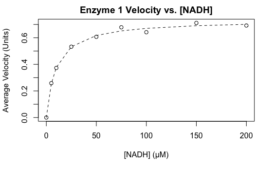

```r
x = hw2table3$X.NADH...µM[1:9]
y = hw2table3$Average.Velocity[1:9]
enz1table = plot(hw2table3$X.NADH...µM., hw2table3$Average.Velocity, main = "Enzyme 1 Velocity vs. [NADH]", xlab = "[NADH] (µM)", ylab = "Average Velocity (Units)")
lines(x, fitted(line), lty = 2, col = "black", lwd = 1)
```

```r
line = nls(y~vmax*x/(km+x))
```

```
No starting values specified for some parameters.
Initializing ‘vmax’, ‘km’ to '1.'.
Consider specifying 'start' or using a selfStart model
```

```r
line
```

```
Nonlinear regression model
  model: y ~ vmax * x/(km + x)
   data: parent.frame()
  vmax     km
0.7341 9.4777
 residual sum-of-squares: 0.002214

Number of iterations to convergence: 6
Achieved convergence tolerance: 9.195e-08
```

```r
RSS = sum(residuals(line)^2)
TSS = sum((y - mean(y))^2)
R.square = 1 - (RSS/TSS)
R.square
```

```
[1] 0.9952948
```

We repeat for Enzyme 2

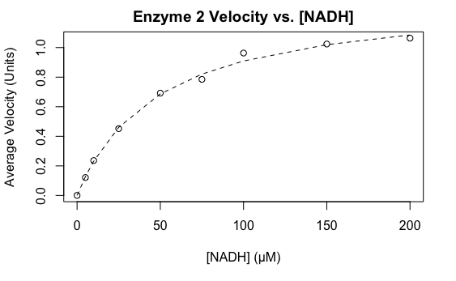

```r
x2 = hw2table4$X.NADH...µM[1:9]
y2 = hw2table4$Average.Velocity[1:9]
enz2table = plot(hw2table4$X.NADH...µM., hw2table4$Average.Velocity, main = "Enzyme 2 Velocity vs. [NADH]", xlab = "[NADH] (µM)", ylab = "Average Velocity (Units)")
lines(x2, fitted(line), lty = 2, col = "black", lwd = 1)
```

```r
line = nls(y2~vmax*x2/(km+x2))
```

```
No starting values specified for some parameters.
Initializing ‘vmax’, ‘km’ to '1.'.
Consider specifying 'start' or using a selfStart model
```

```r
line
```

```
Nonlinear regression model
  model: y2 ~ vmax * x2/(km + x2)
   data: parent.frame()
  vmax     km
 1.346 47.962
 residual sum-of-squares: 0.004793

Number of iterations to convergence: 6
Achieved convergence tolerance: 4.868e-06
```

```r
RSS = sum(residuals(line)^2)
TSS = sum((y - mean(y))^2)
R.square = 1 - (RSS/TSS)
R.square
```

```
[1] 0.9898138
```

5/7/20 Today I’ll work on the last and final worksheet from my STA 100 class. Next week, I plan to learn how to do Differential Expression Analysis.

```r
  outliersBwt
```

```
  [1]   1   2   3   4   5   6   7   8   9  10  11  12  13  14  15  16  17
 [18]  18  19  20  21  22  23  24  25  26  27  28  29  30  31  32  33  34
 [35]  35  36  37  38  39  40  41  42  43  44  45  46  47  48  49  50  51
 [52]  52  53  54  55  56  57  58  59  60  61  62  63  64  65  66  67  68
 [69]  69  70  71  72  73  74  75  76  77  78  79  80  81  82  83  84  85
 [86]  86  87  88  89  90  91  92  93  94  95  96  97  98  99 100 101 102
[103] 103 104 105 106 107 108 109 110 111 112 113 114 115 116 117 118 119
[120] 120 121 122 123 124 125 126 127 128 129 130 131 132 133 134 135 136
[137] 137 138 139 140 141 142 143 144
```